# Performance Analysis of Paxos Consensus Implementation

```python
import glob
import itertools
import os

import matplotlib.pyplot as plt
import numpy as np
import pandas as pd
```

Experiment settings:

```python
n_players = [2,3,4,5,6]
intervals = [5,20,75,250,1000]
```

Pull and clean data:

```python
data = []
file_template = "Num Players:{n}-interval: {interval}-performance.log"
for n in n_players:
    for interval in intervals:
        filename = file_template.format(n=n, interval=interval)
        files = glob.glob(os.path.join("data", filename + ".*"))
        pid = 1
        for file in files:
            f = open(file)
            unparsed_entries = f.read().split("\n")[:-1]
            move_num = 1
            for entry in unparsed_entries:
                cur_data = {}
                cur_data["n_players"] = n
                cur_data["interval"] = interval
                cur_data["pid"] = pid
                cur_data["accept_duration"] = entry.split(" ")[0]
                cur_data["move_pid"] = entry.split(" ")[2]
                cur_data["move_num"] = move_num
                data.append(cur_data)
                move_num += 1
            pid += 1

df = pd.DataFrame(data)
df = df.astype('int')
```

```python
df.head()
```

|  | n_players | interval | pid | accept_duration | move_pid | move_num |
| --- | --- | --- | --- | --- | --- | --- |
| 0 | 2 | 5 | 1 | 114 | 2 | 1 |
| 1 | 2 | 5 | 1 | 41 | 2 | 2 |
| 2 | 2 | 5 | 1 | 21 | 2 | 3 |
| 3 | 2 | 5 | 1 | 15 | 2 | 4 |
| 4 | 2 | 5 | 1 | 13 | 2 | 5 |

## Accept Duration over Number of Players

In order to gain an understanding on whether an increase in number of players changes the accept duration of a proposed move, we plot the average accept duration (averaged over all runs) over the number of processes.

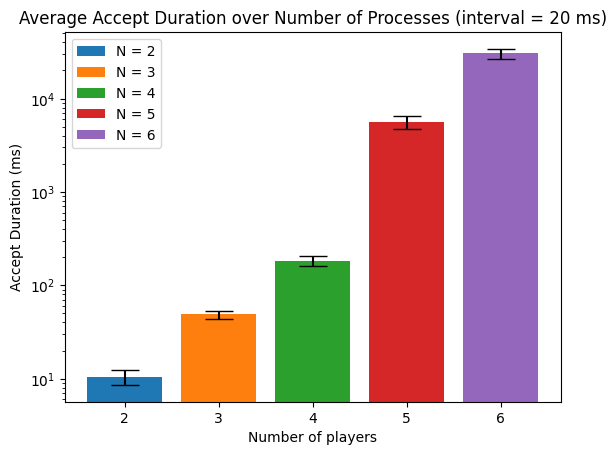

```python
interval = 20
for n in n_players:
    sub_df = df[(df["n_players"] == n) & (df["interval"] == interval)]
    avg_accept = sub_df["accept_duration"].mean()
    std_accept = np.std(sub_df["accept_duration"]) / np.sqrt(len(sub_df["accept_duration"]))
    plt.bar(n, avg_accept, label=f"N = {n}", yerr=std_accept, capsize = 10)
plt.yscale("log")
plt.legend(loc = "upper left")
plt.xlabel("Number of players")
plt.ylabel("Accept Duration (ms)")
plt.title(f"Average Accept Duration over Number of Processes (interval = {interval} ms)")
plt.show()
```

We see a dramatic increase in accept duration as the number of players increases. What about for different intervals? Let's make the same plot, but for all other intervals to see if there's a dramatic change in any other cases.

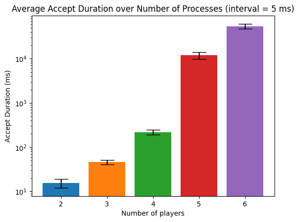

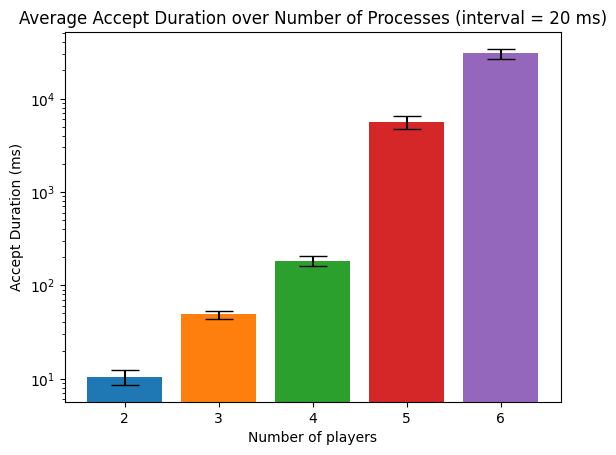

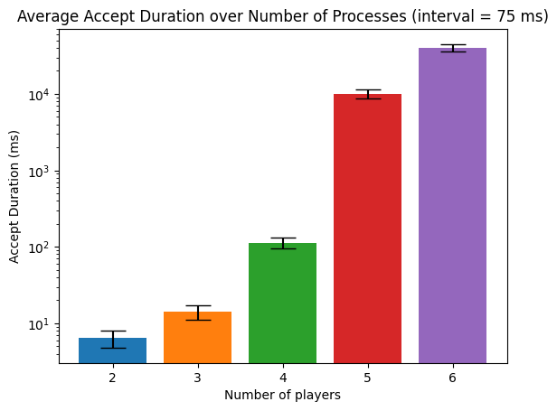

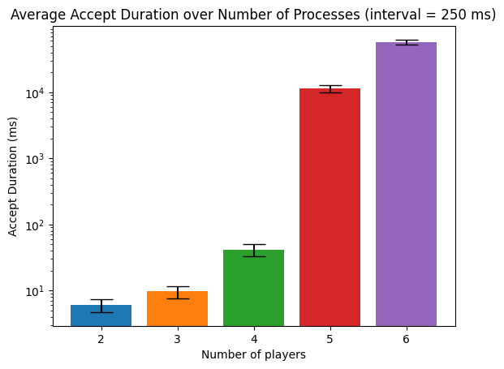

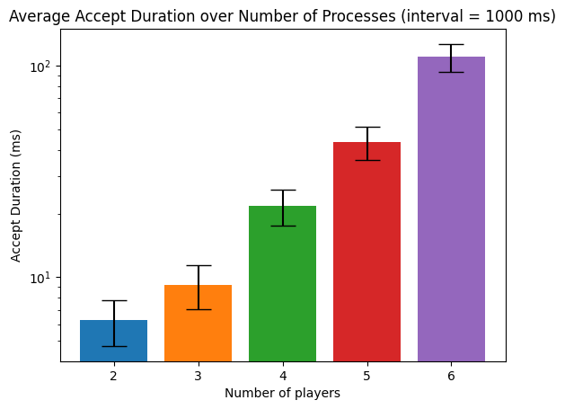

```python
for i in range(len(intervals)):
    for n in n_players:
        interval = intervals[i]
        sub_df = df[(df["n_players"] == n) & (df["interval"] == interval)]
        avg_accept = sub_df["accept_duration"].mean()
        std_accept = np.std(sub_df["accept_duration"]) / np.sqrt(len(sub_df["accept_duration"]))
        plt.bar(n, avg_accept, label=f"N = {n}", yerr=std_accept, capsize = 10)
    plt.yscale("log")
    plt.xlabel("Number of players")
    plt.ylabel("Accept Duration (ms)")
    plt.title(f"Average Accept Duration over Number of Processes (interval = {interval} ms)")
    plt.show()
```

Most of the cases look the same, except for the case where interval = 1000. In this case, we see an overall decrease in mean accept duration, as well as much larger standard deviation. This indicates that our systems performs better if moves are more sporadic.

We also observe that, the standard deviation of accept durations is generally larger (in relation to accept duration) for lower player numbers.

## Accept Duration over Player ID

For this section we will observe the accept duration for the moves of each individual player.

```python
def plot_accept_over_pid(interval, n):
    for pid in range(1,n+1):
        sub_df = df[(df["move_pid"] == pid) & (df["interval"] == interval) & (df["n_players"] == n)]
        avg_accept = sub_df["accept_duration"].mean()
        std_accept = np.std(sub_df["accept_duration"]) / np.sqrt(len(sub_df["accept_duration"]))
        plt.bar(pid, avg_accept, label=f"pid = {pid}", yerr=std_accept, capsize = 10)
    plt.yscale("log")
    plt.legend(loc = "upper left")
    plt.xlabel("Number of players")
    plt.ylabel("Accept Duration (ms)")
    plt.title(f"Average Accept Duration over PID (interval = {interval} ms, N = {n})")
    plt.show()
```

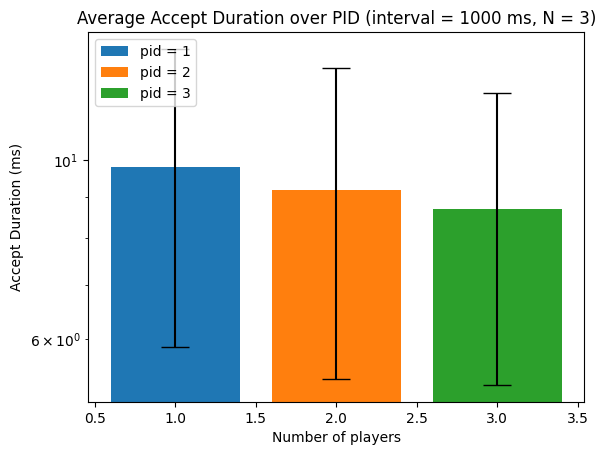

```python
plot_accept_over_pid(interval = 1000, n = 3)
```

For n=3 and interval=1000, we see a somewhat uniform distribution of accept durations of number of players, with a slight bias towards the players with higher pid's having lower accept durations.

Let's increase the number of players to see if this trend persists.

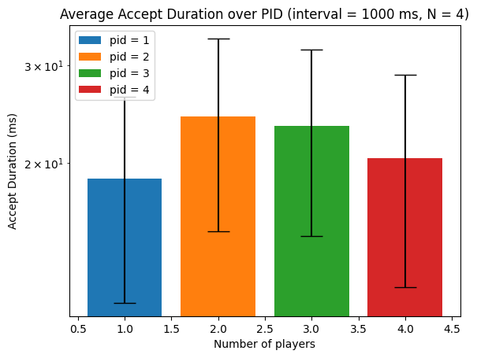

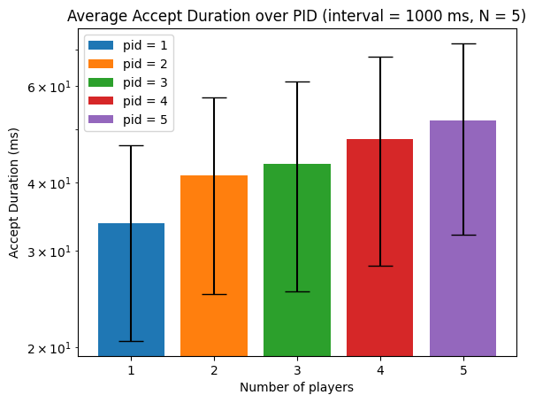

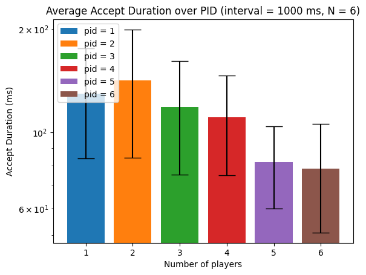

```python
plot_accept_over_pid(interval = 1000, n = 4)
plot_accept_over_pid(interval = 1000, n = 5)
plot_accept_over_pid(interval = 1000, n = 6)
```

For higher number of players, we do not observe the same trend: suggesting that this trend in the data does not persist with more players. For N > 3 there is no clear pattern to this pattern.

Now let's decrease the interval to see if the bias persists.

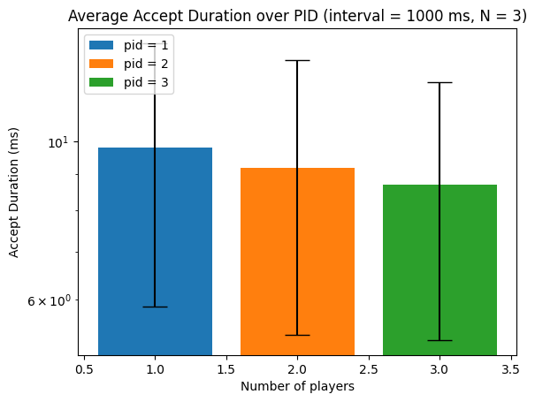

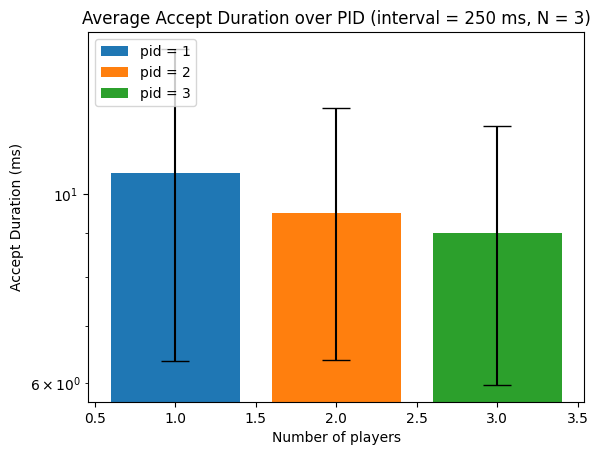

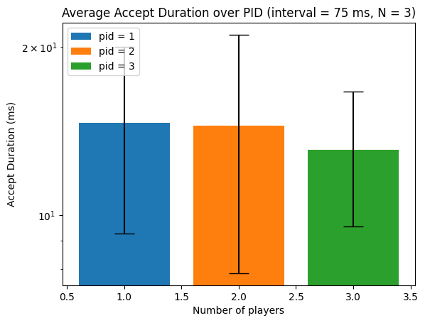

```python
plot_accept_over_pid(interval = 1000, n = 3)
plot_accept_over_pid(interval = 250, n = 3)
plot_accept_over_pid(interval = 75, n = 3)
```

Although mostly uniform, the data suggests a slight bias towards the players with higher pid for N=3. This slight skew most likely arises from our bid initialization procedure, which uses the pid.

## Move rate over interval length

Finally, we observe the effect of decreasing interval length on the move rate. We hypothesize that a lower interval will result in a lower move rate, since the system will be more overwhelmed with proposals which increases the livelihood of livelocks.

```python
def plot_move_rate():
    plt.figure(figsize=(10,6))
    for n in n_players:
        sub_dfs = [df[(df["interval"] == interval) & (df["n_players"] == n)] for interval in intervals]
        move_rates = [1 / sub_df["accept_duration"].mean() for sub_df in sub_dfs]
        move_rates_err = [1 / sub_df["accept_duration"].std() for sub_df in sub_dfs]
        plt.errorbar(intervals, move_rates, label=f"N = {n}", yerr=move_rates_err, fmt='-o', linewidth=2)
        plt.yscale("log")
        plt.xscale("log")
    plt.legend(loc = "lower right")
    plt.gca().invert_xaxis()
    plt.xlabel("Interval")
    plt.ylabel("Move Rate (1/ms)")
    plt.title(f"Average Move rate over Interval")
    plt.show()
```

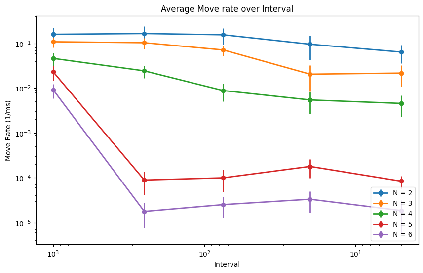

```python
plot_move_rate()
```